# Epidemiological Report - COVID-19

Hugo Soubrier

`2022-05-29`

## **Overview**

- In Fulton County, and over this period, the **attack rate** is of 747.14 (CI 742.24–752.08) per 10 000.
- Amongst all cases of known hospitalisation status, at least 5297 (10.7%) have been **hospitalised**, but 32482 (39.6%) still have an **unknown** status
- Using only cases with known outcome, the **Case Fatality Ratio** is of 3.37% (CI 3.20–3.55), but importantly, 123 (0.1%) cases are under review, and 42302 (51.5%) of cases missing outcome status.

## **Person**

Since the start of the outbreak there was, 43299 (52.7%) female cases and 38393 (46.8%) male cases.

There is 409 (0.5%) cases with missing data on Sex, and 49 (0.1%) cases with missing data on Age.

### Age and Sex distributions

Distribution of cases per **Age groups** and **case gender**

| Age group | male cases (n) | % | female cases (n) | % | unknown cases (n) | % |
| --- | --- | --- | --- | --- | --- | --- |
| < 10 | 1423 | 3.71 | 1398 | 3.23 | 18 | 4.40 |
| 10 - 20 | 4473 | 11.65 | 4679 | 10.81 | 49 | 11.98 |
| 20 - 30 | 8280 | 21.57 | 10243 | 23.66 | 86 | 21.03 |
| 30 - 40 | 7333 | 19.10 | 8200 | 18.94 | 82 | 20.05 |
| 40 - 50 | 5949 | 15.50 | 6551 | 15.13 | 50 | 12.22 |
| 50 - 60 | 5339 | 13.91 | 5587 | 12.90 | 45 | 11.00 |
| 60 - 70 | 3126 | 8.14 | 3274 | 7.56 | 28 | 6.85 |
| 70 + | 2455 | 6.39 | 3345 | 7.73 | 39 | 9.54 |
| unknown | 15 | 0.04 | 22 | 0.05 | 12 | 2.93 |

### Hospitalisations

This section investigates the Hospitalisations due to COVID throughout Age groups and sex.

Overall Hospitalisation rates is of 10.68% (CI 10.41–10.95), but 32482 (39.6%) still have an **unknown** status.

#### Age group

The age group, 70 + had the greatest hospitalisation rate of 44.61% (43.00–46.23).

Hospitalisation rates per **Age groups**

| Age groups | hospitalisations | population | Hosp. rate | 95%-CI |
| --- | --- | --- | --- | --- |
| < 10 | 61 | 2005 | 3.04 | (2.38–3.89) |
| 10 - 20 | 80 | 5677 | 1.41 | (1.13–1.75) |
| 20 - 30 | 372 | 10792 | 3.45 | (3.12–3.81) |
| 30 - 40 | 575 | 9389 | 6.12 | (5.66–6.63) |
| 40 - 50 | 667 | 7603 | 8.77 | (8.16–9.43) |
| 50 - 60 | 982 | 6588 | 14.91 | (14.07–15.79) |
| 60 - 70 | 936 | 3917 | 23.90 | (22.59–25.26) |
| 70 + | 1622 | 3636 | 44.61 | (43.00–46.23) |
| unknown | 2 | 12 | 16.67 | (4.70–44.80) |

#### Sex

Hopsitalisations rates remained similar between Male (11.22% (10.82–11.64)) and Female (10.22% (9.86–10.59) )

Hospitalisation rates per **Sex**

| Sex | hospitalisations | population | Hosp. rate | 95%-CI |
| --- | --- | --- | --- | --- |
| male | 2582 | 23003 | 11.22 | (10.82–11.64) |
| female | 2710 | 26524 | 10.22 | (9.86–10.59) |
| unknown | 5 | 92 | 5.43 | (2.34–12.10) |

### COVID Deaths

This section looks into the CFR within Age groups and sex.

Using only cases with known outcome, the Overall CFR is of 3.37% (CI 3.20–3.55).

Importantly, 123 (0.1%) cases are **under review**, while 42302 (51.5%) have unknown **outcome**.

#### Age group

Distribution of **COVID CFR** per **Age group**

| Age groups | deaths | population | CFR | 95%-CI |
| --- | --- | --- | --- | --- |
| < 10 | 0 | 1620 | 0.00 | (0.00–0.24) |
| 10 - 20 | 1 | 4630 | 0.02 | (0.00–0.12) |
| 20 - 30 | 6 | 8700 | 0.07 | (0.03–0.15) |
| 30 - 40 | 27 | 7517 | 0.36 | (0.25–0.52) |
| 40 - 50 | 43 | 6086 | 0.71 | (0.52–0.95) |
| 50 - 60 | 125 | 5148 | 2.43 | (2.04–2.89) |
| 60 - 70 | 252 | 3097 | 8.14 | (7.23–9.15) |
| 70 + | 884 | 2871 | 30.79 | (29.13–32.50) |
| unknown | 0 | 7 | 0.00 | (0.00–35.43) |

#### Sex

Distribution of **COVID CFR** per **Sex**

| Sex | deaths | population | CFR | 95%-CI |
| --- | --- | --- | --- | --- |
| male | 705 | 18440 | 3.82 | (3.56–4.11) |
| female | 633 | 21183 | 2.99 | (2.77–3.23) |
| unknown | 0 | 53 | 0.00 | (0.00–6.76) |

## **Time**

### Main Epicurve

The peak of the outbreak was reached on week `2020-W53`, with a total of `3615` cases. `122` cases had missing dates, and they were excluded from the epicurves.

[interactive chart not shown]

### Epicurves by groups

[interactive chart not shown]

### Weekly Attack Rates, Hospitalisation rates and CFR

[interactive chart not shown]

## **Place**

### Cases map

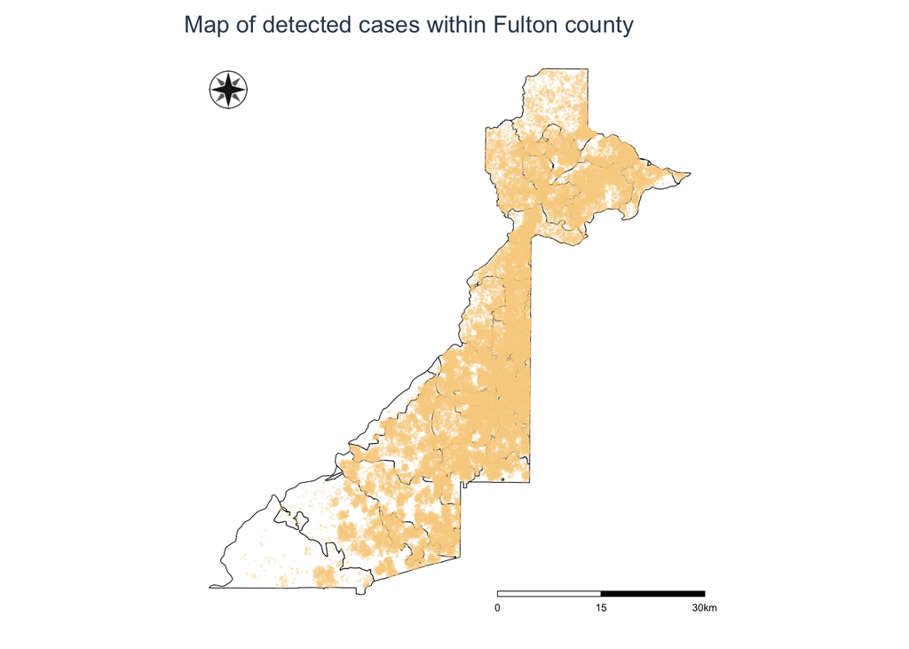

### Chloropleths maps

[output not shown]